# Datos hidrológicos

Andrés Roberto Rivera Arrieta - B86559

## Cargando los datos del archivo CSV dentro de RStudio.

Es importante asegurarse fijar el “working directory” en el folder donde se encuentre el archivo CSV, ya que si no el programa RStudio no puede hallar el archivo. Esto se logra mediante la función `setwd("C:/Users/[[nombre del usuario]]/[[dirección que de directamente al folder donde se encuentra el archivo]")`. La función `head(inp)` le ayuda a uno a verificar que se escogió el archivo correcto mostrando el comienzo de dicho documento; la función `dim(inp)` le da a uno las dimensiones del documento, en este caso siendo 3845 líneas y 3 columnas.

```r
inp <- read.csv("FDC.csv", na.strings="")
head(inp)
```

```
##      Tiempo Pandora.mm..637km2. Banano.mm..90km2.
## 1 6/22/1973                7.46             21.02
## 2 6/23/1973                6.17             14.78
## 3 6/24/1973                6.32             27.65
## 4 6/25/1973                7.80             19.68
## 5 6/26/1973                7.72             15.17
## 6 6/27/1973                7.83             23.14
```

```r
dim(inp)
```

```
## [1] 3845    3
```

## Graficación de los datos.

Una vez cargados los datos del CSV en la memoria, se procede a graficar los datos de la columna 2 y columna 3 del archivo CSV.

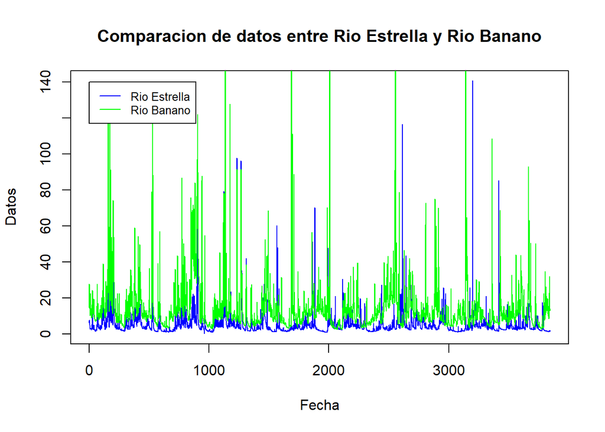

```r
#Graficando la comparacion entre los datos de las dos columnas

plot(inp[,2], type = "l", col="blue",
     main= 'Comparacion de datos entre Rio Estrella y Rio Banano',
     xlab = 'Fecha', ylab = 'Datos')
lines(inp[,3],col="green")
legend(1, 140, legend=c("Rio Estrella", "Rio Banano"),
       col=c("blue","green"),lty=1:1, cex=0.8)
```

### Resumen de las variables e histogramas de estas.

La función `summary(inp[,2:3])` nos da un resumen de los datos presentes en las columnas 2 (Río Estrella) y 3 (Río Banano), presentando datos como: mínimo, 1° cuarto, mediana, media, 3° cuarto, y máximo. La función `hist` nos da un histograma de los datos de cada columna.

```r
#Resumen de las variables e histogramas
summary(inp[,2:3])
```

```
##  Pandora.mm..637km2. Banano.mm..90km2.
##  Min.   :  0.180     Min.   :  2.43
##  1st Qu.:  2.390     1st Qu.:  6.88
##  Median :  3.590     Median : 10.18
##  Mean   :  5.459     Mean   : 14.28
##  3rd Qu.:  5.900     3rd Qu.: 15.46
##  Max.   :140.650     Max.   :384.00
```

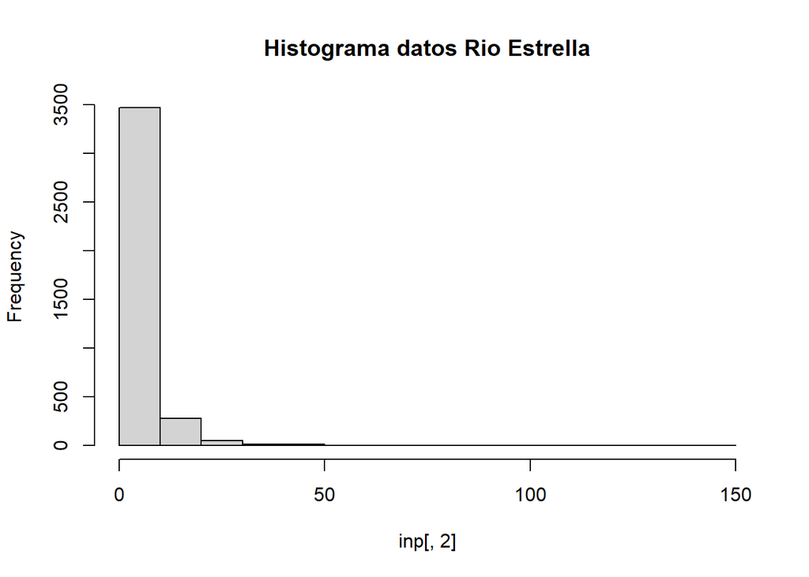

```r
hist(inp[,2], main =
       'Histograma datos Rio Estrella')
```

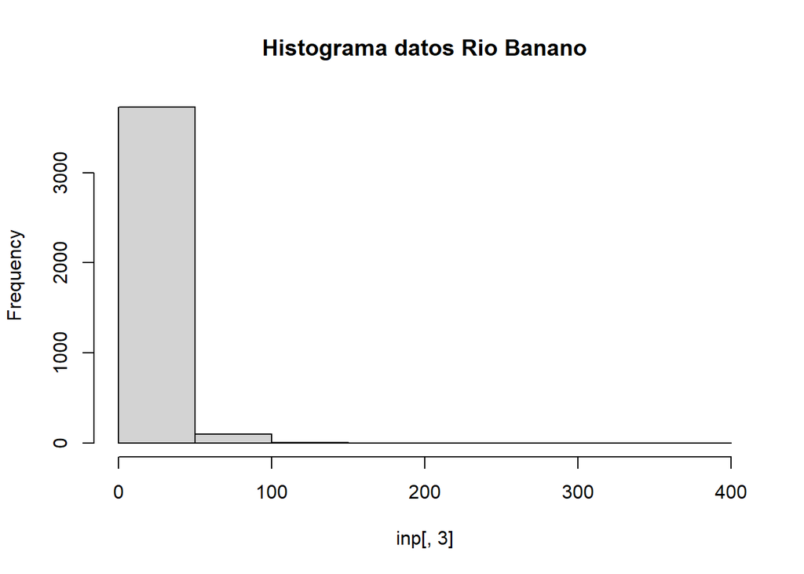

```r
hist(inp[,3], main =
       'Histograma datos Rio Banano')
```

## Nombrando las columnas del dataframe.

La función `names` tiene como propósito darle nombre a las columnas de las variables del dataframe.

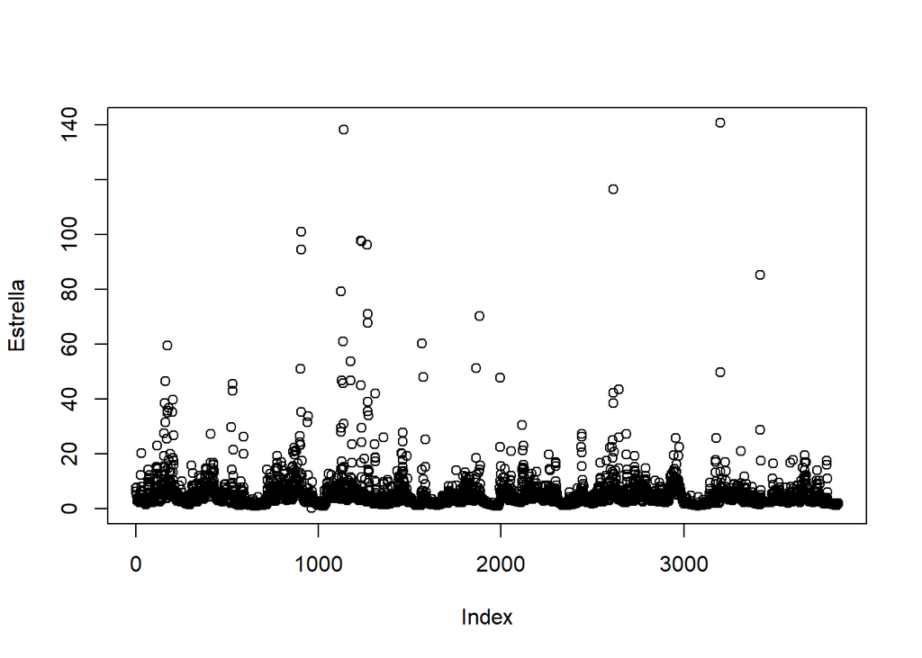

```r
#Nombrando las columnas
names(inp) <- c("fecha", "Estrella", "Banano")
attach(inp)
plot(Estrella)
```

En este caso se establece que los nombres de las columnas, en el orden que están en el dataframe, corresponden a la fecha en que se extrajeron los datos, los datos correspondientes al Río Estrella, y los datos de Río Banano. La siguiente función, `attach`, sirve para adjuntar estos nombres a la base de datos, facilitando así la redacción del código ya que no se ocuparía seguir utilizando los comandos de [,2] haciendo referencia a Río Estrella y [,3] haciendo referencia a Río Banano. Esto facilita además la comprensión del código a terceros.

### Agregando el valor de fecha a la columna 1

```r
#Agregando el valor de fecha a la columna 1
Tempdate <- strptime(inp[,1], format= "%d/%m/%Y")
```

## Calculando el mean annual streamflow (MAQ).

```r
#Calculando el mean annual streamflow (MAQ)
MAQ_Estrella <- tapply(inp[,2], format(Tempdate, format= "%Y"), FUN=sum)
MAQ_Banano <- tapply(inp[,3], format(Tempdate, format= "%Y"), FUN=sum)
```

### Comparando los MAQ por medio de un gráfico.

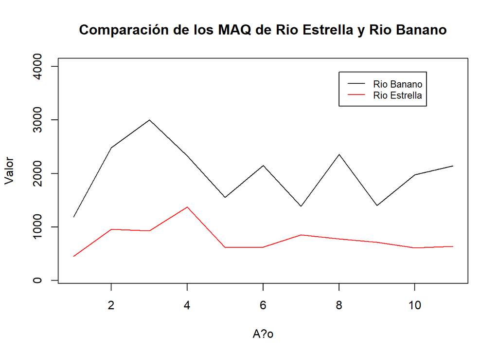

```r
#Comparando MAQs
plot(MAQ_Banano, ylim = c(100,4000),type = "l", col="black",
     main= 'Comparación de los MAQ de Rio Estrella y Rio Banano',
     xlab = 'A?o', ylab= 'Valor')
lines(MAQ_Estrella, col="Red")
legend(8, 3900, legend=c("Rio Banano", "Rio Estrella"),
       col=c("black","red"),lty=1:1, cex=0.8)
```

## Creando nuevos dataframes.

La función `write.csv` permite crear nuevos archivos CSV a partir de `values` que uno haya establecido previamente, tal como lo es en este caso MAQ_Estrella y MAQ_Banano. En este caso se creó un único archivo CSV con ambos `values`.

```r
#Creando nuevos dataframes
write.csv(rbind(MAQ_Estrella, MAQ_Banano), file= "MAQ.csv")
```

### Calculando el mean monthly streamflow.

```r
MMQ_Estrella <- tapply(inp[,2], format(Tempdate, format= "%m"), FUN=sum)
MMQ_Banano <- tapply(inp[,3], format(Tempdate, format= "%m"), FUN=sum)
```

## Análisis de correlación

Las funciones `corinp` e `inp.lm` permite ver la relación entre los dos sets de variables, permitiendo además escoger el método por el cual se obtendrán los datos.

```r
#Analisis de correlacion
corinp <- cor(inp[,2:3], method= "spearman")

inp.lm <- lm (inp[,2] ~ inp[,3], data=inp)
summary(inp.lm)
```

```
##
## Call:
## lm(formula = inp[, 2] ~ inp[, 3], data = inp)
##
## Residuals:
##     Min      1Q  Median      3Q     Max
## -71.297  -2.267  -1.155   0.774 135.889
##
## Coefficients:
##             Estimate Std. Error t value Pr(>|t|)
## (Intercept)  2.70503    0.15174   17.83   <2e-16 ***
## inp[, 3]     0.19290    0.00707   27.28   <2e-16 ***
## ---
## Signif. codes:  0 '***' 0.001 '**' 0.01 '*' 0.05 '.' 0.1 ' ' 1
##
## Residual standard error: 7.025 on 3843 degrees of freedom
## Multiple R-squared:  0.1623, Adjusted R-squared:  0.162
## F-statistic: 744.4 on 1 and 3843 DF,  p-value: < 2.2e-16
```

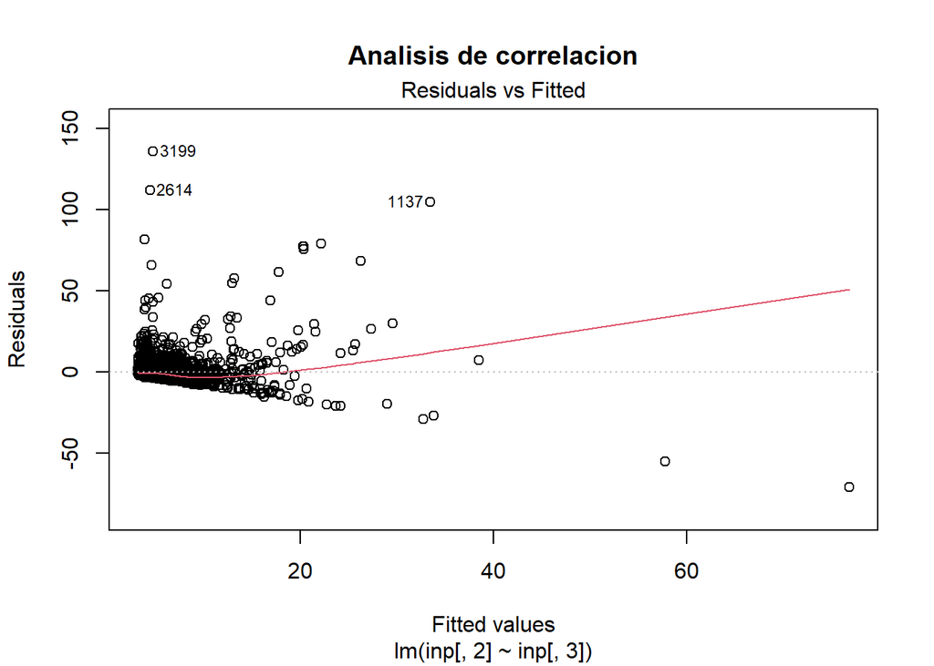

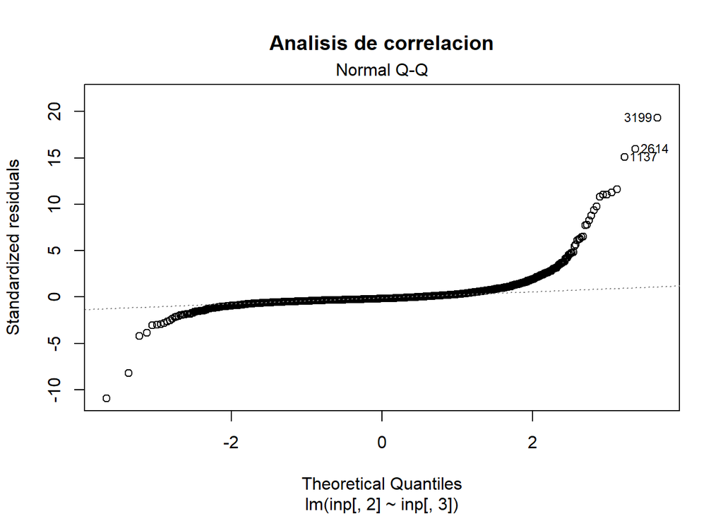

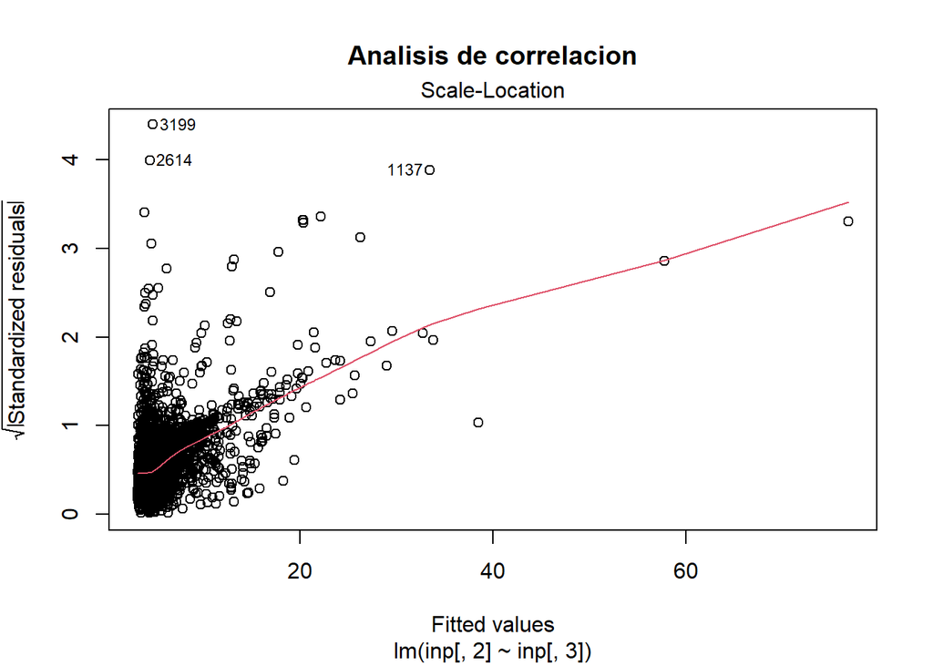

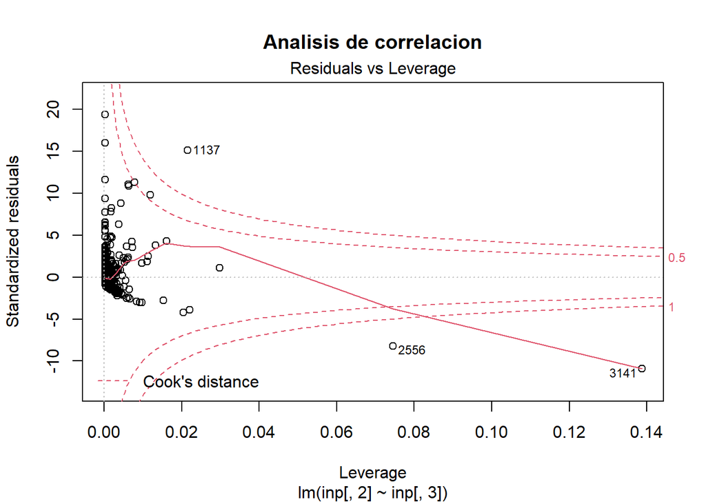

```r
plot(inp.lm, main = 'Analisis de correlacion',)
```